# Project: Investigate a Dataset - [Movies Dataset]

- Introduction
- Data Wrangling
- Exploratory Data Analysis
- Conclusions

## Introduction

### Dataset Description

> Columns of the dataset:
> - 'id' : The id of each movie as an integer
> - 'imdb_id' : Another id for each movie but in a string form
> - 'popularity' : it tells us how popular was each movie
> - 'budget' : how much dollars was paid to make the movie
> - 'revenue' : how much dollars they earned from the movie
> - 'original_title' : the title of the movie
> - 'cast' : the actors who participated in the movie
> - 'homepage' : The url for the website of each movie
> - 'director' : the director of the movie
> - 'tagline' : the slogan of the movie
> - 'keywords' : some words that fall under the scope of the film
> - 'overview' : a very short overview about the film
> - 'runtime'
> - 'genres' : they are the style of the movie (adventure, action)
> - 'production_companies' : The companies that helped in the film production
> - 'release_date' : The full date when the movie released
> - 'vote_count' : the number of votes on the film
> - 'vote_average' : the average vote on each film
> - 'release_year' : the year when the movie was released
> - 'budget_adj' : The budget of the movie in terms of 2010 dollars
> - 'revenue_adj' : The revenue of the movie in terms of 2010 dollars

> ● This data set contains information and characterestics of about 10,000 movies collected from The Movie Database, including user ratings , revenue , vote average and many other characterestics

> ● There are columns like ‘cast’ and ‘genres’ contain multiple values separated by pipe (|) characters.

> ● The final two columns ending with “_adj” show the budget and revenue of the associated movie in terms of 2010 dollars, accounting for inflation over time.

### Questions for Analysis:

### Question 1 : What are the most 5 popular genres in movies ?

### Question 2 : What are the properties associated with with the movies of the most popular genres ?

### Question 3 : What are the highest 5 movies in profit ?

### Question 4 : Does the vot_average has a relation with the profit

## Importing required packages :

```python
# Setting up import statements for all of the packages that are used
import pandas as pd
import numpy as np
import seaborn as sb
```

## Data Wrangling :

## General Properties :

### Loading the dataset :

```python
# Loading the data
df = pd.read_csv("/kaggle/input/movies-dataset/tmdb-movies.csv")
df.T
```

|  | 0 | 1 | 2 | 3 | 4 | 5 | 6 | 7 | 8 | 9 | ... | 10856 | 10857 | 10858 | 10859 | 10860 | 10861 | 10862 | 10863 | 10864 | 10865 |
| --- | --- | --- | --- | --- | --- | --- | --- | --- | --- | --- | --- | --- | --- | --- | --- | --- | --- | --- | --- | --- | --- |
| id | 135397 | 76341 | 262500 | 140607 | 168259 | 281957 | 87101 | 286217 | 211672 | 150540 | ... | 20277 | 5921 | 31918 | 20620 | 5060 | 21 | 20379 | 39768 | 21449 | 22293 |
| imdb_id | tt0369610 | tt1392190 | tt2908446 | tt2488496 | tt2820852 | tt1663202 | tt1340138 | tt3659388 | tt2293640 | tt2096673 | ... | tt0061135 | tt0060748 | tt0060921 | tt0060955 | tt0060214 | tt0060371 | tt0060472 | tt0060161 | tt0061177 | tt0060666 |
| popularity | 32.985763 | 28.419936 | 13.112507 | 11.173104 | 9.335014 | 9.1107 | 8.654359 | 7.6674 | 7.404165 | 6.326804 | ... | 0.140934 | 0.131378 | 0.317824 | 0.089072 | 0.087034 | 0.080598 | 0.065543 | 0.065141 | 0.064317 | 0.035919 |
| budget | 150000000 | 150000000 | 110000000 | 200000000 | 190000000 | 135000000 | 155000000 | 108000000 | 74000000 | 175000000 | ... | 0 | 0 | 0 | 0 | 0 | 0 | 0 | 0 | 0 | 19000 |
| revenue | 1513528810 | 378436354 | 295238201 | 2068178225 | 1506249360 | 532950503 | 440603537 | 595380321 | 1156730962 | 853708609 | ... | 0 | 0 | 0 | 0 | 0 | 0 | 0 | 0 | 0 | 0 |
| original_title | Jurassic World | Mad Max: Fury Road | Insurgent | Star Wars: The Force Awakens | Furious 7 | The Revenant | Terminator Genisys | The Martian | Minions | Inside Out | ... | The Ugly Dachshund | Nevada Smith | The Russians Are Coming, The Russians Are Coming | Seconds | Carry On Screaming! | The Endless Summer | Grand Prix | Beregis Avtomobilya | What's Up, Tiger Lily? | Manos: The Hands of Fate |
| cast | Chris Pratt\|Bryce Dallas Howard\|Irrfan Khan\|Vi... | Tom Hardy\|Charlize Theron\|Hugh Keays-Byrne\|Nic... | Shailene Woodley\|Theo James\|Kate Winslet\|Ansel... | Harrison Ford\|Mark Hamill\|Carrie Fisher\|Adam D... | Vin Diesel\|Paul Walker\|Jason Statham\|Michelle ... | Leonardo DiCaprio\|Tom Hardy\|Will Poulter\|Domhn... | Arnold Schwarzenegger\|Jason Clarke\|Emilia Clar... | Matt Damon\|Jessica Chastain\|Kristen Wiig\|Jeff ... | Sandra Bullock\|Jon Hamm\|Michael Keaton\|Allison... | Amy Poehler\|Phyllis Smith\|Richard Kind\|Bill Ha... | ... | Dean Jones\|Suzanne Pleshette\|Charles Ruggles\|K... | Steve McQueen\|Karl Malden\|Brian Keith\|Arthur K... | Carl Reiner\|Eva Marie Saint\|Alan Arkin\|Brian K... | Rock Hudson\|Salome Jens\|John Randolph\|Will Gee... | Kenneth Williams\|Jim Dale\|Harry H. Corbett\|Joa... | Michael Hynson\|Robert August\|Lord 'Tally Ho' B... | James Garner\|Eva Marie Saint\|Yves Montand\|Tosh... | Innokentiy Smoktunovskiy\|Oleg Efremov\|Georgi Z... | Tatsuya Mihashi\|Akiko Wakabayashi\|Mie Hama\|Joh... | Harold P. Warren\|Tom Neyman\|John Reynolds\|Dian... |
| homepage | http://www.jurassicworld.com/ | http://www.madmaxmovie.com/ | http://www.thedivergentseries.movie/#insurgent | http://www.starwars.com/films/star-wars-episod... | http://www.furious7.com/ | http://www.foxmovies.com/movies/the-revenant | http://www.terminatormovie.com/ | http://www.foxmovies.com/movies/the-martian | http://www.minionsmovie.com/ | http://movies.disney.com/inside-out | ... | NaN | NaN | NaN | NaN | NaN | NaN | NaN | NaN | NaN | NaN |
| director | Colin Trevorrow | George Miller | Robert Schwentke | J.J. Abrams | James Wan | Alejandro González Iñárritu | Alan Taylor | Ridley Scott | Kyle Balda\|Pierre Coffin | Pete Docter | ... | Norman Tokar | Henry Hathaway | Norman Jewison | John Frankenheimer | Gerald Thomas | Bruce Brown | John Frankenheimer | Eldar Ryazanov | Woody Allen | Harold P. Warren |
| tagline | The park is open. | What a Lovely Day. | One Choice Can Destroy You | Every generation has a story. | Vengeance Hits Home | (n. One who has returned, as if from the dead.) | Reset the future | Bring Him Home | Before Gru, they had a history of bad bosses | Meet the little voices inside your head. | ... | A HAPPY HONEYMOON GOES TO THE DOGS!...When a G... | Some called him savage- and some called him sa... | IT'S A PLOT! ...to make the world die laughing!! | NaN | Carry On Screaming with the Hilarious CARRY ON... | NaN | Cinerama sweeps YOU into a drama of speed and ... | NaN | WOODY ALLEN STRIKES BACK! | It's Shocking! It's Beyond Your Imagination! |
| keywords | monster\|dna\|tyrannosaurus rex\|velociraptor\|island | future\|chase\|post-apocalyptic\|dystopia\|australia | based on novel\|revolution\|dystopia\|sequel\|dyst... | android\|spaceship\|jedi\|space opera\|3d | car race\|speed\|revenge\|suspense\|car | father-son relationship\|rape\|based on novel\|mo... | saving the world\|artificial intelligence\|cybor... | based on novel\|mars\|nasa\|isolation\|botanist | assistant\|aftercreditsstinger\|duringcreditssti... | dream\|cartoon\|imaginary friend\|animation\|kid | ... | great dane\|dachshund | repayment\|revenge\|native american\|wild west\|ha... | cold war\|russian\|new england | plastic surgery\|suspense | monster\|carry on\|horror spoof | surfer\|surfboard\|surfing | car race\|racing\|formula 1 | car\|trolley\|stealing car | spoof | fire\|gun\|drive\|sacrifice\|flashlight |
| overview | Twenty-two years after the events of Jurassic ... | An apocalyptic story set in the furthest reach... | Beatrice Prior must confront her inner demons ... | Thirty years after defeating the Galactic Empi... | Deckard Shaw seeks revenge against Dominic Tor... | In the 1820s, a frontiersman, Hugh Glass, sets... | The year is 2029. John Connor, leader of the r... | During a manned mission to Mars, Astronaut Mar... | Minions Stuart, Kevin and Bob are recruited by... | Growing up can be a bumpy road, and it's no ex... | ... | The Garrisons (Dean Jones and Suzanne Pleshett... | Nevada Smith is the young son of an Indian mot... | Without hostile intent, a Soviet sub runs agro... | A secret organisation offers wealthy people a ... | The sinister Dr Watt has an evil scheme going.... | The Endless Summer, by Bruce Brown, is one of ... | Grand Prix driver Pete Aron is fired by his te... | An insurance agent who moonlights as a carthie... | In comic Woody Allen's film debut, he took the... | A family gets lost on the road and stumbles up... |
| runtime | 124 | 120 | 119 | 136 | 137 | 156 | 125 | 141 | 91 | 94 | ... | 93 | 128 | 126 | 100 | 87 | 95 | 176 | 94 | 80 | 74 |
| genres | Action\|Adventure\|Science Fiction\|Thriller | Action\|Adventure\|Science Fiction\|Thriller | Adventure\|Science Fiction\|Thriller | Action\|Adventure\|Science Fiction\|Fantasy | Action\|Crime\|Thriller | Western\|Drama\|Adventure\|Thriller | Science Fiction\|Action\|Thriller\|Adventure | Drama\|Adventure\|Science Fiction | Family\|Animation\|Adventure\|Comedy | Comedy\|Animation\|Family | ... | Comedy\|Drama\|Family | Action\|Western | Comedy\|War | Mystery\|Science Fiction\|Thriller\|Drama | Comedy | Documentary | Action\|Adventure\|Drama | Mystery\|Comedy | Action\|Comedy | Horror |
| production_companies | Universal Studios\|Amblin Entertainment\|Legenda... | Village Roadshow Pictures\|Kennedy Miller Produ... | Summit Entertainment\|Mandeville Films\|Red Wago... | Lucasfilm\|Truenorth Productions\|Bad Robot | Universal Pictures\|Original Film\|Media Rights ... | Regency Enterprises\|Appian Way\|CatchPlay\|Anony... | Paramount Pictures\|Skydance Productions | Twentieth Century Fox Film Corporation\|Scott F... | Universal Pictures\|Illumination Entertainment | Walt Disney Pictures\|Pixar Animation Studios\|W... | ... | Walt Disney Pictures | Paramount Pictures\|Solar Productions\|Embassy P... | The Mirisch Corporation | Gibraltar Productions\|Joel Productions\|John Fr... | Peter Rogers Productions\|Anglo-Amalgamated Fil... | Bruce Brown Films | Cherokee Productions\|Joel Productions\|Douglas ... | Mosfilm | Benedict Pictures Corp. | Norm-Iris |
| release_date | 6/9/15 | 5/13/15 | 3/18/15 | 12/15/15 | 4/1/15 | 12/25/15 | 6/23/15 | 9/30/15 | 6/17/15 | 6/9/15 | ... | 2/16/66 | 6/10/66 | 5/25/66 | 10/5/66 | 5/20/66 | 6/15/66 | 12/21/66 | 1/1/66 | 11/2/66 | 11/15/66 |
| vote_count | 5562 | 6185 | 2480 | 5292 | 2947 | 3929 | 2598 | 4572 | 2893 | 3935 | ... | 14 | 10 | 11 | 22 | 13 | 11 | 20 | 11 | 22 | 15 |
| vote_average | 6.5 | 7.1 | 6.3 | 7.5 | 7.3 | 7.2 | 5.8 | 7.6 | 6.5 | 8.0 | ... | 5.7 | 5.9 | 5.5 | 6.6 | 7.0 | 7.4 | 5.7 | 6.5 | 5.4 | 1.5 |
| release_year | 2015 | 2015 | 2015 | 2015 | 2015 | 2015 | 2015 | 2015 | 2015 | 2015 | ... | 1966 | 1966 | 1966 | 1966 | 1966 | 1966 | 1966 | 1966 | 1966 | 1966 |
| budget_adj | 137999939.280026 | 137999939.280026 | 101199955.472019 | 183999919.040035 | 174799923.088033 | 124199945.352024 | 142599937.256027 | 99359956.281619 | 68079970.044813 | 160999929.160031 | ... | 0.0 | 0.0 | 0.0 | 0.0 | 0.0 | 0.0 | 0.0 | 0.0 | 0.0 | 127642.279154 |
| revenue_adj | 1392445892.5238 | 348161292.489031 | 271619025.407628 | 1902723129.80182 | 1385748801.47052 | 490314247.021731 | 405355075.683766 | 547749654.310152 | 1064192016.79551 | 785411574.698907 | ... | 0.0 | 0.0 | 0.0 | 0.0 | 0.0 | 0.0 | 0.0 | 0.0 | 0.0 | 0.0 |

21 rows × 10866 columns

### The dimensions of the data :

```python
df.shape
```

```
(10866, 21)
```

### Inspecting the data :

```python
#columns of the dataset
df.columns
```

```
Index(['id', 'imdb_id', 'popularity', 'budget', 'revenue', 'original_title',
       'cast', 'homepage', 'director', 'tagline', 'keywords', 'overview',
       'runtime', 'genres', 'production_companies', 'release_date',
       'vote_count', 'vote_average', 'release_year', 'budget_adj',
       'revenue_adj'],
      dtype='object')
```

```python
#inspecting data types and look for missing data.
df.info()
```

```
<class 'pandas.core.frame.DataFrame'>
RangeIndex: 10866 entries, 0 to 10865
Data columns (total 21 columns):
 #   Column                Non-Null Count  Dtype
---  ------                --------------  -----
 0   id                    10866 non-null  int64
 1   imdb_id               10856 non-null  object
 2   popularity            10866 non-null  float64
 3   budget                10866 non-null  int64
 4   revenue               10866 non-null  int64
 5   original_title        10866 non-null  object
 6   cast                  10790 non-null  object
 7   homepage              2936 non-null   object
 8   director              10822 non-null  object
 9   tagline               8042 non-null   object
 10  keywords              9373 non-null   object
 11  overview              10862 non-null  object
 12  runtime               10866 non-null  int64
 13  genres                10843 non-null  object
 14  production_companies  9836 non-null   object
 15  release_date          10866 non-null  object
 16  vote_count            10866 non-null  int64
 17  vote_average          10866 non-null  float64
 18  release_year          10866 non-null  int64
 19  budget_adj            10866 non-null  float64
 20  revenue_adj           10866 non-null  float64
dtypes: float64(4), int64(6), object(11)
memory usage: 1.7+ MB
```

```python
#missing cells in each column
pd.isnull(df).sum()
```

```
id                         0
imdb_id                   10
popularity                 0
budget                     0
revenue                    0
original_title             0
cast                      76
homepage                7930
director                  44
tagline                 2824
keywords                1493
overview                   4
runtime                    0
genres                    23
production_companies    1030
release_date               0
vote_count                 0
vote_average               0
release_year               0
budget_adj                 0
revenue_adj                0
dtype: int64
```

```python
#getting summary stastics about the quantitative data in the dataframe
df.describe()
```

|  | id | popularity | budget | revenue | runtime | vote_count | vote_average | release_year | budget_adj | revenue_adj |
| --- | --- | --- | --- | --- | --- | --- | --- | --- | --- | --- |
| count | 10866.000000 | 10866.000000 | 1.086600e+04 | 1.086600e+04 | 10866.000000 | 10866.000000 | 10866.000000 | 10866.000000 | 1.086600e+04 | 1.086600e+04 |
| mean | 66064.177434 | 0.646441 | 1.462570e+07 | 3.982332e+07 | 102.070863 | 217.389748 | 5.974922 | 2001.322658 | 1.755104e+07 | 5.136436e+07 |
| std | 92130.136561 | 1.000185 | 3.091321e+07 | 1.170035e+08 | 31.381405 | 575.619058 | 0.935142 | 12.812941 | 3.430616e+07 | 1.446325e+08 |
| min | 5.000000 | 0.000065 | 0.000000e+00 | 0.000000e+00 | 0.000000 | 10.000000 | 1.500000 | 1960.000000 | 0.000000e+00 | 0.000000e+00 |
| 25% | 10596.250000 | 0.207583 | 0.000000e+00 | 0.000000e+00 | 90.000000 | 17.000000 | 5.400000 | 1995.000000 | 0.000000e+00 | 0.000000e+00 |
| 50% | 20669.000000 | 0.383856 | 0.000000e+00 | 0.000000e+00 | 99.000000 | 38.000000 | 6.000000 | 2006.000000 | 0.000000e+00 | 0.000000e+00 |
| 75% | 75610.000000 | 0.713817 | 1.500000e+07 | 2.400000e+07 | 111.000000 | 145.750000 | 6.600000 | 2011.000000 | 2.085325e+07 | 3.369710e+07 |
| max | 417859.000000 | 32.985763 | 4.250000e+08 | 2.781506e+09 | 900.000000 | 9767.000000 | 9.200000 | 2015.000000 | 4.250000e+08 | 2.827124e+09 |

```python
#getting summary stastics about the categorical data in the dataframe
df.describe(include = 'object')
```

|  | imdb_id | original_title | cast | homepage | director | tagline | keywords | overview | genres | production_companies | release_date |
| --- | --- | --- | --- | --- | --- | --- | --- | --- | --- | --- | --- |
| count | 10856 | 10866 | 10790 | 2936 | 10822 | 8042 | 9373 | 10862 | 10843 | 9836 | 10866 |
| unique | 10855 | 10571 | 10719 | 2896 | 5067 | 7997 | 8804 | 10847 | 2039 | 7445 | 5909 |
| top | tt0411951 | Hamlet | Louis C.K. | http://www.thehungergames.movie/ | Woody Allen | Based on a true story. | woman director | No overview found. | Comedy | Paramount Pictures | 1/1/09 |
| freq | 2 | 4 | 6 | 4 | 45 | 5 | 134 | 13 | 712 | 156 | 28 |

```python
# seeing if there is dublicated rows
df.duplicated().sum()
```

```
1
```

```python
df[df.duplicated()]
```

|  | id | imdb_id | popularity | budget | revenue | original_title | cast | homepage | director | tagline | ... | overview | runtime | genres | production_companies | release_date | vote_count | vote_average | release_year | budget_adj | revenue_adj |
| --- | --- | --- | --- | --- | --- | --- | --- | --- | --- | --- | --- | --- | --- | --- | --- | --- | --- | --- | --- | --- | --- |
| 2090 | 42194 | tt0411951 | 0.59643 | 30000000 | 967000 | TEKKEN | Jon Foo\|Kelly Overton\|Cary-Hiroyuki Tagawa\|Ian... | NaN | Dwight H. Little | Survival is no game | ... | In the year of 2039, after World Wars destroy ... | 92 | Crime\|Drama\|Action\|Thriller\|Science Fiction | Namco\|Light Song Films | 3/20/10 | 110 | 5.0 | 2010 | 30000000.0 | 967000.0 |

1 rows × 21 columns

```python
df[df.duplicated]
df[df['id'] == 42194]
```

|  | id | imdb_id | popularity | budget | revenue | original_title | cast | homepage | director | tagline | ... | overview | runtime | genres | production_companies | release_date | vote_count | vote_average | release_year | budget_adj | revenue_adj |
| --- | --- | --- | --- | --- | --- | --- | --- | --- | --- | --- | --- | --- | --- | --- | --- | --- | --- | --- | --- | --- | --- |
| 2089 | 42194 | tt0411951 | 0.59643 | 30000000 | 967000 | TEKKEN | Jon Foo\|Kelly Overton\|Cary-Hiroyuki Tagawa\|Ian... | NaN | Dwight H. Little | Survival is no game | ... | In the year of 2039, after World Wars destroy ... | 92 | Crime\|Drama\|Action\|Thriller\|Science Fiction | Namco\|Light Song Films | 3/20/10 | 110 | 5.0 | 2010 | 30000000.0 | 967000.0 |
| 2090 | 42194 | tt0411951 | 0.59643 | 30000000 | 967000 | TEKKEN | Jon Foo\|Kelly Overton\|Cary-Hiroyuki Tagawa\|Ian... | NaN | Dwight H. Little | Survival is no game | ... | In the year of 2039, after World Wars destroy ... | 92 | Crime\|Drama\|Action\|Thriller\|Science Fiction | Namco\|Light Song Films | 3/20/10 | 110 | 5.0 | 2010 | 30000000.0 | 967000.0 |

2 rows × 21 columns

```python
#Checking for Missing values in the adjustment of the budget and revenue columns
print("Zero Values in budget adjustment column", df[df['budget_adj'] == 0.0].value_counts().sum())
print("Zero Values in revenue adjustment column", df[df['revenue_adj'] == 0.0].value_counts().sum())
```

```
Zero Values in budget adjustment column 546
Zero Values in revenue adjustment column 546
```

```python
#Cchecking for Missing values in the budget and revenue columns
print("Zero Values in budget column", df[df['budget'] == 0.0].value_counts().sum())
print("Zero Values in revenue column", df[df['revenue'] == 0.0].value_counts().sum())
```

```
Zero Values in budget column 546
Zero Values in revenue column 546
```

## Observations:

> **There is two columns for the Movie ID which is inneccesary**

> **The "id" column Must be an categorical column not numeric**

> **There is a row which is duplicated**

> **Home page column has so many missing vales**

> **There are outliers in the date time column**

> **The datatype of the column "release_date" is object while it must be datetime**

> **There is some columns which will not be used in analysis**

> **Revenue and Budget columns and the adjustment columns of them has many missing values which is a limitation that will affect the summary stastics of them**

> **Creating new column for the profit to ease the analysis**

> **The genres colmns has some missing values and more than one value in the same cell (splitting them in separated rows)**

## Data Cleaning

### Deleting duplicated rows:

```python
df.drop_duplicates(inplace = True)
# Checking that the code worked
df[df.duplicated]
```

|  | id | imdb_id | popularity | budget | revenue | original_title | cast | homepage | director | tagline | ... | overview | runtime | genres | production_companies | release_date | vote_count | vote_average | release_year | budget_adj | revenue_adj |
| --- | --- | --- | --- | --- | --- | --- | --- | --- | --- | --- | --- | --- | --- | --- | --- | --- | --- | --- | --- | --- | --- |

0 rows × 21 columns

### Removing outliers in the date time column :

```python
release_date = []
for cell in df['release_date']:
    if int(cell[-2:]) > 20:
        release_date.append(cell[:-2] + "19" + cell[-2:])
        continue
    else:
        release_date.append(cell[:-2] + "20" + cell[-2:])
        continue

df['release_date'] = release_date
df.tail().T
```

|  | 10861 | 10862 | 10863 | 10864 | 10865 |
| --- | --- | --- | --- | --- | --- |
| id | 21 | 20379 | 39768 | 21449 | 22293 |
| imdb_id | tt0060371 | tt0060472 | tt0060161 | tt0061177 | tt0060666 |
| popularity | 0.080598 | 0.065543 | 0.065141 | 0.064317 | 0.035919 |
| budget | 0 | 0 | 0 | 0 | 19000 |
| revenue | 0 | 0 | 0 | 0 | 0 |
| original_title | The Endless Summer | Grand Prix | Beregis Avtomobilya | What's Up, Tiger Lily? | Manos: The Hands of Fate |
| cast | Michael Hynson\|Robert August\|Lord 'Tally Ho' B... | James Garner\|Eva Marie Saint\|Yves Montand\|Tosh... | Innokentiy Smoktunovskiy\|Oleg Efremov\|Georgi Z... | Tatsuya Mihashi\|Akiko Wakabayashi\|Mie Hama\|Joh... | Harold P. Warren\|Tom Neyman\|John Reynolds\|Dian... |
| homepage | NaN | NaN | NaN | NaN | NaN |
| director | Bruce Brown | John Frankenheimer | Eldar Ryazanov | Woody Allen | Harold P. Warren |
| tagline | NaN | Cinerama sweeps YOU into a drama of speed and ... | NaN | WOODY ALLEN STRIKES BACK! | It's Shocking! It's Beyond Your Imagination! |
| keywords | surfer\|surfboard\|surfing | car race\|racing\|formula 1 | car\|trolley\|stealing car | spoof | fire\|gun\|drive\|sacrifice\|flashlight |
| overview | The Endless Summer, by Bruce Brown, is one of ... | Grand Prix driver Pete Aron is fired by his te... | An insurance agent who moonlights as a carthie... | In comic Woody Allen's film debut, he took the... | A family gets lost on the road and stumbles up... |
| runtime | 95 | 176 | 94 | 80 | 74 |
| genres | Documentary | Action\|Adventure\|Drama | Mystery\|Comedy | Action\|Comedy | Horror |
| production_companies | Bruce Brown Films | Cherokee Productions\|Joel Productions\|Douglas ... | Mosfilm | Benedict Pictures Corp. | Norm-Iris |
| release_date | 6/15/1966 | 12/21/1966 | 1/1/1966 | 11/2/1966 | 11/15/1966 |
| vote_count | 11 | 20 | 11 | 22 | 15 |
| vote_average | 7.4 | 5.7 | 6.5 | 5.4 | 1.5 |
| release_year | 1966 | 1966 | 1966 | 1966 | 1966 |
| budget_adj | 0.0 | 0.0 | 0.0 | 0.0 | 127642.279154 |
| revenue_adj | 0.0 | 0.0 | 0.0 | 0.0 | 0.0 |

### Adjusting datatypes of some columns

```python
#inspecting data types
df.info()
```

```
<class 'pandas.core.frame.DataFrame'>
Index: 10865 entries, 0 to 10865
Data columns (total 21 columns):
 #   Column                Non-Null Count  Dtype
---  ------                --------------  -----
 0   id                    10865 non-null  int64
 1   imdb_id               10855 non-null  object
 2   popularity            10865 non-null  float64
 3   budget                10865 non-null  int64
 4   revenue               10865 non-null  int64
 5   original_title        10865 non-null  object
 6   cast                  10789 non-null  object
 7   homepage              2936 non-null   object
 8   director              10821 non-null  object
 9   tagline               8041 non-null   object
 10  keywords              9372 non-null   object
 11  overview              10861 non-null  object
 12  runtime               10865 non-null  int64
 13  genres                10842 non-null  object
 14  production_companies  9835 non-null   object
 15  release_date          10865 non-null  object
 16  vote_count            10865 non-null  int64
 17  vote_average          10865 non-null  float64
 18  release_year          10865 non-null  int64
 19  budget_adj            10865 non-null  float64
 20  revenue_adj           10865 non-null  float64
dtypes: float64(4), int64(6), object(11)
memory usage: 1.8+ MB
```

```python
# adjusting the data type of the columns id
df = df.astype({
    'id': 'object'
})
```

```python
# adjusting datatype of the release date column
df['release_date'] = pd.to_datetime(df['release_date'], format="mixed", dayfirst = True)
```

```python
df.info()
```

```
<class 'pandas.core.frame.DataFrame'>
Index: 10865 entries, 0 to 10865
Data columns (total 21 columns):
 #   Column                Non-Null Count  Dtype
---  ------                --------------  -----
 0   id                    10865 non-null  object
 1   imdb_id               10855 non-null  object
 2   popularity            10865 non-null  float64
 3   budget                10865 non-null  int64
 4   revenue               10865 non-null  int64
 5   original_title        10865 non-null  object
 6   cast                  10789 non-null  object
 7   homepage              2936 non-null   object
 8   director              10821 non-null  object
 9   tagline               8041 non-null   object
 10  keywords              9372 non-null   object
 11  overview              10861 non-null  object
 12  runtime               10865 non-null  int64
 13  genres                10842 non-null  object
 14  production_companies  9835 non-null   object
 15  release_date          10865 non-null  datetime64[ns]
 16  vote_count            10865 non-null  int64
 17  vote_average          10865 non-null  float64
 18  release_year          10865 non-null  int64
 19  budget_adj            10865 non-null  float64
 20  revenue_adj           10865 non-null  float64
dtypes: datetime64[ns](1), float64(4), int64(5), object(11)
memory usage: 1.8+ MB
```

### Removing unneccassry columns:

```python
df.head().T
```

|  | 0 | 1 | 2 | 3 | 4 |
| --- | --- | --- | --- | --- | --- |
| id | 135397 | 76341 | 262500 | 140607 | 168259 |
| imdb_id | tt0369610 | tt1392190 | tt2908446 | tt2488496 | tt2820852 |
| popularity | 32.985763 | 28.419936 | 13.112507 | 11.173104 | 9.335014 |
| budget | 150000000 | 150000000 | 110000000 | 200000000 | 190000000 |
| revenue | 1513528810 | 378436354 | 295238201 | 2068178225 | 1506249360 |
| original_title | Jurassic World | Mad Max: Fury Road | Insurgent | Star Wars: The Force Awakens | Furious 7 |
| cast | Chris Pratt\|Bryce Dallas Howard\|Irrfan Khan\|Vi... | Tom Hardy\|Charlize Theron\|Hugh Keays-Byrne\|Nic... | Shailene Woodley\|Theo James\|Kate Winslet\|Ansel... | Harrison Ford\|Mark Hamill\|Carrie Fisher\|Adam D... | Vin Diesel\|Paul Walker\|Jason Statham\|Michelle ... |
| homepage | http://www.jurassicworld.com/ | http://www.madmaxmovie.com/ | http://www.thedivergentseries.movie/#insurgent | http://www.starwars.com/films/star-wars-episod... | http://www.furious7.com/ |
| director | Colin Trevorrow | George Miller | Robert Schwentke | J.J. Abrams | James Wan |
| tagline | The park is open. | What a Lovely Day. | One Choice Can Destroy You | Every generation has a story. | Vengeance Hits Home |
| keywords | monster\|dna\|tyrannosaurus rex\|velociraptor\|island | future\|chase\|post-apocalyptic\|dystopia\|australia | based on novel\|revolution\|dystopia\|sequel\|dyst... | android\|spaceship\|jedi\|space opera\|3d | car race\|speed\|revenge\|suspense\|car |
| overview | Twenty-two years after the events of Jurassic ... | An apocalyptic story set in the furthest reach... | Beatrice Prior must confront her inner demons ... | Thirty years after defeating the Galactic Empi... | Deckard Shaw seeks revenge against Dominic Tor... |
| runtime | 124 | 120 | 119 | 136 | 137 |
| genres | Action\|Adventure\|Science Fiction\|Thriller | Action\|Adventure\|Science Fiction\|Thriller | Adventure\|Science Fiction\|Thriller | Action\|Adventure\|Science Fiction\|Fantasy | Action\|Crime\|Thriller |
| production_companies | Universal Studios\|Amblin Entertainment\|Legenda... | Village Roadshow Pictures\|Kennedy Miller Produ... | Summit Entertainment\|Mandeville Films\|Red Wago... | Lucasfilm\|Truenorth Productions\|Bad Robot | Universal Pictures\|Original Film\|Media Rights ... |
| release_date | 2015-09-06 00:00:00 | 2015-05-13 00:00:00 | 2015-03-18 00:00:00 | 2015-12-15 00:00:00 | 2015-01-04 00:00:00 |
| vote_count | 5562 | 6185 | 2480 | 5292 | 2947 |
| vote_average | 6.5 | 7.1 | 6.3 | 7.5 | 7.3 |
| release_year | 2015 | 2015 | 2015 | 2015 | 2015 |
| budget_adj | 137999939.280026 | 137999939.280026 | 101199955.472019 | 183999919.040035 | 174799923.088033 |
| revenue_adj | 1392445892.5238 | 348161292.489031 | 271619025.407628 | 1902723129.80182 | 1385748801.47052 |

```python
# creating new dataset for only the columns that will be used in exploratory analysis
df_adj = df.drop(
        columns =
        ['id',
        'imdb_id',
        'cast',
        'homepage',
        'tagline',
        'overview',
        'production_companies',
        'budget',
        'revenue',
        'keywords'],
        axis = 1)
```

```python
df_adj.head(3)
```

|  | popularity | original_title | director | runtime | genres | release_date | vote_count | vote_average | release_year | budget_adj | revenue_adj |
| --- | --- | --- | --- | --- | --- | --- | --- | --- | --- | --- | --- |
| 0 | 32.985763 | Jurassic World | Colin Trevorrow | 124 | Action\|Adventure\|Science Fiction\|Thriller | 2015-09-06 | 5562 | 6.5 | 2015 | 1.379999e+08 | 1.392446e+09 |
| 1 | 28.419936 | Mad Max: Fury Road | George Miller | 120 | Action\|Adventure\|Science Fiction\|Thriller | 2015-05-13 | 6185 | 7.1 | 2015 | 1.379999e+08 | 3.481613e+08 |
| 2 | 13.112507 | Insurgent | Robert Schwentke | 119 | Adventure\|Science Fiction\|Thriller | 2015-03-18 | 2480 | 6.3 | 2015 | 1.012000e+08 | 2.716190e+08 |

### Filling zero values in the budget and revenue columns with the mean

```python
#Asigning the value of the mean for the budget column and the revenue column in variables
budget_mean = df_adj['budget_adj'].mean()
print(budget_mean)
revenue_mean = df_adj['revenue_adj'].mean()
print(revenue_mean)
```

```
17549894.037320547
51369001.75884263
```

```python
#This function is for Replacing the zero values in the columns by the mean
def replacing_zeros(column, value):
    #here it assigns the mean of the column that will replace the zero values
    column_mean = df_adj[column].mean()
    #it loops over the values of the given column and checks if it equals to 0.0
    for cell in df_adj[column]:
        if cell == 0.0:
            #it the value = 0 it replaces it with the mean of the column
            df_adj[column].replace(cell, column_mean, inplace=True)
```

```python
#Applying the previous function on these two columns that have zero values
replacing_zeros('budget_adj', budget_mean)
replacing_zeros('revenue_adj', revenue_mean)
```

```python
# checking that the code worked
df_adj[df_adj['budget_adj'] == 0.0]
df_adj[df_adj['revenue_adj'] == 0.0]
```

|  | popularity | original_title | director | runtime | genres | release_date | vote_count | vote_average | release_year | budget_adj | revenue_adj |
| --- | --- | --- | --- | --- | --- | --- | --- | --- | --- | --- | --- |

```python
#Checking the mean again after assigning the zero values with the mean
print("New mean: ",df_adj['budget_adj'].mean())
print("Old mean : ",budget_mean)
print("\n")
print("New mean: ",df_adj['revenue_adj'].mean())
print("Old mean :",revenue_mean)
```

```
New mean:  26750464.349016618
Old mean :  17549894.037320547


New mean:  79812252.06544153
Old mean : 51369001.75884263
```

> We conclude that the mean after changing the zero values with the previous mean increases which will affect the exploratory analysis in the following steps

### Creating New column for the profit to ease the analysis

```python
df_adj['profit'] = df_adj['revenue_adj'] - df_adj['budget_adj']
```

```python
df_adj[df_adj['profit']== 0.0]
```

|  | popularity | original_title | director | runtime | genres | release_date | vote_count | vote_average | release_year | budget_adj | revenue_adj | profit |
| --- | --- | --- | --- | --- | --- | --- | --- | --- | --- | --- | --- | --- |
| 5198 | 0.126182 | Les Clefs de bagnole | Laurent Baffie | 90 | Comedy | 2003-10-12 | 12 | 4.8 | 2003 | 674722.876405 | 674722.876405 | 0.0 |
| 7250 | 0.082116 | Narco | Tristan Aurouet\|Gilles Lellouche | 105 | Comedy | 2004-01-12 | 26 | 5.8 | 2004 | 950406.410959 | 950406.410959 | 0.0 |
| 7813 | 0.065543 | Loose Change: Final Cut | Dylan Avery | 129 | Documentary | 2007-11-11 | 12 | 5.1 | 2007 | 6310.011496 | 6310.011496 | 0.0 |
| 10777 | 0.439210 | F.I.S.T. | Norman Jewison | 145 | Drama\|Action | 1978-04-26 | 13 | 6.7 | 1978 | 36.769708 | 36.769708 | 0.0 |

```python
df_adj.head(3)
```

|  | popularity | original_title | director | runtime | genres | release_date | vote_count | vote_average | release_year | budget_adj | revenue_adj | profit |
| --- | --- | --- | --- | --- | --- | --- | --- | --- | --- | --- | --- | --- |
| 0 | 32.985763 | Jurassic World | Colin Trevorrow | 124 | Action\|Adventure\|Science Fiction\|Thriller | 2015-09-06 | 5562 | 6.5 | 2015 | 1.379999e+08 | 1.392446e+09 | 1.254446e+09 |
| 1 | 28.419936 | Mad Max: Fury Road | George Miller | 120 | Action\|Adventure\|Science Fiction\|Thriller | 2015-05-13 | 6185 | 7.1 | 2015 | 1.379999e+08 | 3.481613e+08 | 2.101614e+08 |
| 2 | 13.112507 | Insurgent | Robert Schwentke | 119 | Adventure\|Science Fiction\|Thriller | 2015-03-18 | 2480 | 6.3 | 2015 | 1.012000e+08 | 2.716190e+08 | 1.704191e+08 |

### Dropping Null values in the genres column:

```python
df_adj.shape
```

```
(10865, 12)
```

```python
# Displaying null values in genres column
df_adj[pd.isnull(df_adj['genres'])]
```

|  | popularity | original_title | director | runtime | genres | release_date | vote_count | vote_average | release_year | budget_adj | revenue_adj | profit |
| --- | --- | --- | --- | --- | --- | --- | --- | --- | --- | --- | --- | --- |
| 424 | 0.244648 | Belli di papÃ | Guido Chiesa | 100 | NaN | 2015-10-29 | 21 | 6.1 | 2015 | 1.754989e+07 | 5.136900e+07 | 3.381911e+07 |
| 620 | 0.129696 | All Hallows' Eve 2 | Antonio Padovan\|Bryan Norton\|Marc Roussel\|Ryan... | 90 | NaN | 2015-06-10 | 13 | 5.0 | 2015 | 1.754989e+07 | 5.136900e+07 | 3.381911e+07 |
| 997 | 0.330431 | Star Wars Rebels: Spark of Rebellion | Steward Lee\|Steven G. Lee | 44 | NaN | 2014-03-10 | 13 | 6.8 | 2014 | 1.754989e+07 | 5.136900e+07 | 3.381911e+07 |
| 1712 | 0.302095 | Prayers for Bobby | Russell Mulcahy | 88 | NaN | 2009-02-27 | 57 | 7.4 | 2009 | 1.754989e+07 | 5.136900e+07 | 3.381911e+07 |
| 1897 | 0.020701 | Jonas Brothers: The Concert Experience | Bruce Hendricks | 76 | NaN | 2009-02-27 | 11 | 7.0 | 2009 | 1.754989e+07 | 5.136900e+07 | 3.381911e+07 |
| 2370 | 0.081892 | Freshman Father | Michael Scott | 0 | NaN | 2010-05-06 | 12 | 5.8 | 2010 | 1.754989e+07 | 5.136900e+07 | 3.381911e+07 |
| 2376 | 0.068411 | Doctor Who: A Christmas Carol | NaN | 62 | NaN | 2010-12-25 | 11 | 7.7 | 2010 | 1.754989e+07 | 5.136900e+07 | 3.381911e+07 |
| 2853 | 0.130018 | Vizontele | YÄ±lmaz ErdoÄŸan | 110 | NaN | 2001-02-02 | 12 | 7.2 | 2001 | 1.754989e+07 | 5.136900e+07 | 3.381911e+07 |
| 3279 | 0.145331 | ì•„ê¸°ì™€ ë‚˜ | Kim Jin-Yeong | 96 | NaN | 2008-08-13 | 11 | 6.1 | 2008 | 1.754989e+07 | 5.136900e+07 | 3.381911e+07 |
| 4547 | 0.520520 | London 2012 Olympic Opening Ceremony: Isles of... | Danny Boyle | 220 | NaN | 2012-07-27 | 12 | 8.3 | 2012 | 1.754989e+07 | 5.136900e+07 | 3.381911e+07 |
| 4732 | 0.235911 | The Scapegoat | Charles Sturridge | 100 | NaN | 2012-09-09 | 12 | 6.2 | 2012 | 1.754989e+07 | 5.136900e+07 | 3.381911e+07 |
| 4797 | 0.167501 | Doctor Who: The Snowmen | NaN | 60 | NaN | 2012-12-25 | 10 | 7.8 | 2012 | 1.754989e+07 | 5.136900e+07 | 3.381911e+07 |
| 4890 | 0.083202 | Cousin Ben Troop Screening | Wes Anderson | 2 | NaN | 2012-01-01 | 14 | 7.0 | 2012 | 1.754989e+07 | 5.136900e+07 | 3.381911e+07 |
| 5830 | 0.248944 | Doctor Who: The Time of the Doctor | James Payne | 60 | NaN | 2013-12-25 | 26 | 8.5 | 2013 | 1.754989e+07 | 5.136900e+07 | 3.381911e+07 |
| 5934 | 0.067433 | Prada: Candy | Wes Anderson\|Roman Coppola | 3 | NaN | 2013-03-25 | 27 | 6.9 | 2013 | 1.754989e+07 | 5.136900e+07 | 3.381911e+07 |
| 6043 | 0.039080 | Bombay Talkies | Anurag Kashyap\|Dibakar Banerjee\|Zoya Akhtar\|Ka... | 127 | NaN | 2013-03-05 | 12 | 5.9 | 2013 | 1.754989e+07 | 5.136900e+07 | 3.381911e+07 |
| 6530 | 0.092724 | Saw Rebirth | Jeff Shuter\|Daniel Viney | 6 | NaN | 2005-10-24 | 24 | 5.9 | 2005 | 1.754989e+07 | 5.136900e+07 | 3.381911e+07 |
| 8234 | 0.028874 | Viaggi di nozze | Carlo Verdone | 103 | NaN | 1995-12-15 | 44 | 6.7 | 1995 | 1.754989e+07 | 5.136900e+07 | 3.381911e+07 |
| 8614 | 0.273934 | T2 3-D: Battle Across Time | James Cameron | 12 | NaN | 1996-01-01 | 14 | 6.7 | 1996 | 1.754989e+07 | 5.136900e+07 | 3.381911e+07 |
| 8878 | 0.038045 | Mom's Got a Date With a Vampire | Steve Boyum | 85 | NaN | 2000-10-13 | 16 | 5.4 | 2000 | 1.754989e+07 | 5.136900e+07 | 3.381911e+07 |
| 9307 | 0.094652 | Goldeneye | Don Boyd | 105 | NaN | 1989-08-26 | 10 | 5.3 | 1989 | 1.754989e+07 | 5.136900e+07 | 3.381911e+07 |
| 9799 | 0.175008 | The Amputee | David Lynch | 5 | NaN | 1974-01-01 | 11 | 5.0 | 1974 | 1.754989e+07 | 5.136900e+07 | 3.381911e+07 |
| 10659 | 0.344172 | The Party at Kitty and Stud's | Morton Lewis | 71 | NaN | 1970-10-02 | 10 | 3.0 | 1970 | 2.808184e+04 | 5.136900e+07 | 5.134092e+07 |

```python
# The sum of null values in genres
pd.isnull(df_adj['genres']).sum()
```

```
23
```

```python
#Removing null values in genres column
df_adj.dropna(inplace = True, subset = ['genres'])
```

```python
# Checking that the code worked
pd.isnull(df_adj['genres']).sum()
```

```
0
```

### Separating the values in each cell in the genres column to separated rows:

```python
'''Making a dataframe that have the values of the genres column
separated in separated rows because some of them have multiple values'''
#Making the new dataframe for the generated genres
separated_genres = df_adj
#First Making the values of every row in the genres in a list
separated_genres['genres'] = separated_genres['genres'].str.split("|")
```

```python
#Then separating them in multiple rows
separated_genres = separated_genres.explode('genres')
separated_genres
```

|  | popularity | original_title | director | runtime | genres | release_date | vote_count | vote_average | release_year | budget_adj | revenue_adj | profit |
| --- | --- | --- | --- | --- | --- | --- | --- | --- | --- | --- | --- | --- |
| 0 | 32.985763 | Jurassic World | Colin Trevorrow | 124 | Action | 2015-09-06 | 5562 | 6.5 | 2015 | 1.379999e+08 | 1.392446e+09 | 1.254446e+09 |
| 0 | 32.985763 | Jurassic World | Colin Trevorrow | 124 | Adventure | 2015-09-06 | 5562 | 6.5 | 2015 | 1.379999e+08 | 1.392446e+09 | 1.254446e+09 |
| 0 | 32.985763 | Jurassic World | Colin Trevorrow | 124 | Science Fiction | 2015-09-06 | 5562 | 6.5 | 2015 | 1.379999e+08 | 1.392446e+09 | 1.254446e+09 |
| 0 | 32.985763 | Jurassic World | Colin Trevorrow | 124 | Thriller | 2015-09-06 | 5562 | 6.5 | 2015 | 1.379999e+08 | 1.392446e+09 | 1.254446e+09 |
| 1 | 28.419936 | Mad Max: Fury Road | George Miller | 120 | Action | 2015-05-13 | 6185 | 7.1 | 2015 | 1.379999e+08 | 3.481613e+08 | 2.101614e+08 |
| ... | ... | ... | ... | ... | ... | ... | ... | ... | ... | ... | ... | ... |
| 10863 | 0.065141 | Beregis Avtomobilya | Eldar Ryazanov | 94 | Mystery | 1966-01-01 | 11 | 6.5 | 1966 | 1.754989e+07 | 5.136900e+07 | 3.381911e+07 |
| 10863 | 0.065141 | Beregis Avtomobilya | Eldar Ryazanov | 94 | Comedy | 1966-01-01 | 11 | 6.5 | 1966 | 1.754989e+07 | 5.136900e+07 | 3.381911e+07 |
| 10864 | 0.064317 | What's Up, Tiger Lily? | Woody Allen | 80 | Action | 1966-02-11 | 22 | 5.4 | 1966 | 1.754989e+07 | 5.136900e+07 | 3.381911e+07 |
| 10864 | 0.064317 | What's Up, Tiger Lily? | Woody Allen | 80 | Comedy | 1966-02-11 | 22 | 5.4 | 1966 | 1.754989e+07 | 5.136900e+07 | 3.381911e+07 |
| 10865 | 0.035919 | Manos: The Hands of Fate | Harold P. Warren | 74 | Horror | 1966-11-15 | 15 | 1.5 | 1966 | 1.276423e+05 | 5.136900e+07 | 5.124136e+07 |

26955 rows × 12 columns

### Summary stastics of the data after cleaning

```python
df_adj
```

|  | popularity | original_title | director | runtime | genres | release_date | vote_count | vote_average | release_year | budget_adj | revenue_adj | profit |
| --- | --- | --- | --- | --- | --- | --- | --- | --- | --- | --- | --- | --- |
| 0 | 32.985763 | Jurassic World | Colin Trevorrow | 124 | [Action, Adventure, Science Fiction, Thriller] | 2015-09-06 | 5562 | 6.5 | 2015 | 1.379999e+08 | 1.392446e+09 | 1.254446e+09 |
| 1 | 28.419936 | Mad Max: Fury Road | George Miller | 120 | [Action, Adventure, Science Fiction, Thriller] | 2015-05-13 | 6185 | 7.1 | 2015 | 1.379999e+08 | 3.481613e+08 | 2.101614e+08 |
| 2 | 13.112507 | Insurgent | Robert Schwentke | 119 | [Adventure, Science Fiction, Thriller] | 2015-03-18 | 2480 | 6.3 | 2015 | 1.012000e+08 | 2.716190e+08 | 1.704191e+08 |
| 3 | 11.173104 | Star Wars: The Force Awakens | J.J. Abrams | 136 | [Action, Adventure, Science Fiction, Fantasy] | 2015-12-15 | 5292 | 7.5 | 2015 | 1.839999e+08 | 1.902723e+09 | 1.718723e+09 |
| 4 | 9.335014 | Furious 7 | James Wan | 137 | [Action, Crime, Thriller] | 2015-01-04 | 2947 | 7.3 | 2015 | 1.747999e+08 | 1.385749e+09 | 1.210949e+09 |
| ... | ... | ... | ... | ... | ... | ... | ... | ... | ... | ... | ... | ... |
| 10861 | 0.080598 | The Endless Summer | Bruce Brown | 95 | [Documentary] | 1966-06-15 | 11 | 7.4 | 1966 | 1.754989e+07 | 5.136900e+07 | 3.381911e+07 |
| 10862 | 0.065543 | Grand Prix | John Frankenheimer | 176 | [Action, Adventure, Drama] | 1966-12-21 | 20 | 5.7 | 1966 | 1.754989e+07 | 5.136900e+07 | 3.381911e+07 |
| 10863 | 0.065141 | Beregis Avtomobilya | Eldar Ryazanov | 94 | [Mystery, Comedy] | 1966-01-01 | 11 | 6.5 | 1966 | 1.754989e+07 | 5.136900e+07 | 3.381911e+07 |
| 10864 | 0.064317 | What's Up, Tiger Lily? | Woody Allen | 80 | [Action, Comedy] | 1966-02-11 | 22 | 5.4 | 1966 | 1.754989e+07 | 5.136900e+07 | 3.381911e+07 |
| 10865 | 0.035919 | Manos: The Hands of Fate | Harold P. Warren | 74 | [Horror] | 1966-11-15 | 15 | 1.5 | 1966 | 1.276423e+05 | 5.136900e+07 | 5.124136e+07 |

10842 rows × 12 columns

```python
df_adj.info()
```

```
<class 'pandas.core.frame.DataFrame'>
Index: 10842 entries, 0 to 10865
Data columns (total 12 columns):
 #   Column          Non-Null Count  Dtype
---  ------          --------------  -----
 0   popularity      10842 non-null  float64
 1   original_title  10842 non-null  object
 2   director        10800 non-null  object
 3   runtime         10842 non-null  int64
 4   genres          10842 non-null  object
 5   release_date    10842 non-null  datetime64[ns]
 6   vote_count      10842 non-null  int64
 7   vote_average    10842 non-null  float64
 8   release_year    10842 non-null  int64
 9   budget_adj      10842 non-null  float64
 10  revenue_adj     10842 non-null  float64
 11  profit          10842 non-null  float64
dtypes: datetime64[ns](1), float64(5), int64(3), object(3)
memory usage: 1.1+ MB
```

```python
df_adj.describe()
```

|  | popularity | runtime | release_date | vote_count | vote_average | release_year | budget_adj | revenue_adj | profit |
| --- | --- | --- | --- | --- | --- | --- | --- | --- | --- |
| count | 10842.000000 | 10842.000000 | 10842 | 10842.000000 | 10842.000000 | 10842.000000 | 1.084200e+04 | 1.084200e+04 | 1.084200e+04 |
| mean | 0.647461 | 102.138443 | 2001-10-26 23:15:30.381848320 | 217.823649 | 5.974064 | 2001.314794 | 2.677160e+07 | 7.987259e+07 | 5.310099e+07 |
| min | 0.000065 | 0.000000 | 1960-01-01 00:00:00 | 10.000000 | 1.500000 | 1960.000000 | 9.210911e-01 | 2.370705e+00 | -4.139124e+08 |
| 25% | 0.208210 | 90.000000 | 1995-03-03 00:00:00 | 17.000000 | 5.400000 | 1995.000000 | 1.754989e+07 | 5.136900e+07 | 1.997065e+07 |
| 50% | 0.384532 | 99.000000 | 2006-01-21 12:00:00 | 38.000000 | 6.000000 | 2006.000000 | 1.754989e+07 | 5.136900e+07 | 3.381911e+07 |
| 75% | 0.715393 | 111.000000 | 2011-10-05 00:00:00 | 146.000000 | 6.600000 | 2011.000000 | 2.092507e+07 | 5.136900e+07 | 3.907999e+07 |
| max | 32.985763 | 900.000000 | 2015-12-31 00:00:00 | 9767.000000 | 9.200000 | 2015.000000 | 4.250000e+08 | 2.827124e+09 | 2.750137e+09 |
| std | 1.001032 | 31.294612 | NaN | 576.180993 | 0.934257 | 12.813617 | 3.053852e+07 | 1.367032e+08 | 1.208024e+08 |

```python
separated_genres.describe(include = 'object')
```

|  | original_title | director | genres |
| --- | --- | --- | --- |
| count | 26955 | 26864 | 26955 |
| unique | 10548 | 5056 | 20 |
| top | Annie | Woody Allen | Drama |
| freq | 11 | 105 | 4760 |

```python
df_adj.describe(include = 'object')
```

|  | original_title | director | genres |
| --- | --- | --- | --- |
| count | 10842 | 10800 | 10842 |
| unique | 10548 | 5056 | 2039 |
| top | Hamlet | Woody Allen | [Comedy] |
| freq | 4 | 45 | 712 |

## Exploratory Data Analysis

### Question 1 : What are the most 5 popular genres in movies ?

```python
separated_genres
```

|  | popularity | original_title | director | runtime | genres | release_date | vote_count | vote_average | release_year | budget_adj | revenue_adj | profit |
| --- | --- | --- | --- | --- | --- | --- | --- | --- | --- | --- | --- | --- |
| 0 | 32.985763 | Jurassic World | Colin Trevorrow | 124 | Action | 2015-09-06 | 5562 | 6.5 | 2015 | 1.379999e+08 | 1.392446e+09 | 1.254446e+09 |
| 0 | 32.985763 | Jurassic World | Colin Trevorrow | 124 | Adventure | 2015-09-06 | 5562 | 6.5 | 2015 | 1.379999e+08 | 1.392446e+09 | 1.254446e+09 |
| 0 | 32.985763 | Jurassic World | Colin Trevorrow | 124 | Science Fiction | 2015-09-06 | 5562 | 6.5 | 2015 | 1.379999e+08 | 1.392446e+09 | 1.254446e+09 |
| 0 | 32.985763 | Jurassic World | Colin Trevorrow | 124 | Thriller | 2015-09-06 | 5562 | 6.5 | 2015 | 1.379999e+08 | 1.392446e+09 | 1.254446e+09 |
| 1 | 28.419936 | Mad Max: Fury Road | George Miller | 120 | Action | 2015-05-13 | 6185 | 7.1 | 2015 | 1.379999e+08 | 3.481613e+08 | 2.101614e+08 |
| ... | ... | ... | ... | ... | ... | ... | ... | ... | ... | ... | ... | ... |
| 10863 | 0.065141 | Beregis Avtomobilya | Eldar Ryazanov | 94 | Mystery | 1966-01-01 | 11 | 6.5 | 1966 | 1.754989e+07 | 5.136900e+07 | 3.381911e+07 |
| 10863 | 0.065141 | Beregis Avtomobilya | Eldar Ryazanov | 94 | Comedy | 1966-01-01 | 11 | 6.5 | 1966 | 1.754989e+07 | 5.136900e+07 | 3.381911e+07 |
| 10864 | 0.064317 | What's Up, Tiger Lily? | Woody Allen | 80 | Action | 1966-02-11 | 22 | 5.4 | 1966 | 1.754989e+07 | 5.136900e+07 | 3.381911e+07 |
| 10864 | 0.064317 | What's Up, Tiger Lily? | Woody Allen | 80 | Comedy | 1966-02-11 | 22 | 5.4 | 1966 | 1.754989e+07 | 5.136900e+07 | 3.381911e+07 |
| 10865 | 0.035919 | Manos: The Hands of Fate | Harold P. Warren | 74 | Horror | 1966-11-15 | 15 | 1.5 | 1966 | 1.276423e+05 | 5.136900e+07 | 5.124136e+07 |

26955 rows × 12 columns

```python
#A dataframe that have each one of the genres with their count in the dataset descendingly
genres_counted = pd.DataFrame(separated_genres['genres'].value_counts())
genres_counted
```

| genres | count |
| --- | --- |
| Drama | 4760 |
| Comedy | 3793 |
| Thriller | 2907 |
| Action | 2384 |
| Romance | 1712 |
| Horror | 1637 |
| Adventure | 1471 |
| Crime | 1354 |
| Family | 1231 |
| Science Fiction | 1229 |
| Fantasy | 916 |
| Mystery | 810 |
| Animation | 699 |
| Documentary | 520 |
| Music | 408 |
| History | 334 |
| War | 270 |
| Foreign | 188 |
| TV Movie | 167 |
| Western | 165 |

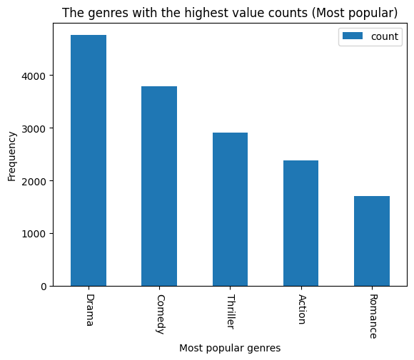

```python
#plotting the 5 most popular genres between movies frequency
genres_counted[:5].plot.bar(rot = 270, title = "The genres with the highest value counts (Most popular)", ylabel = "Frequency",xlabel = "Most popular genres", legend = True)
```

### Question 2 : What are the properties associated with with the movies of the most popular genres ?

```python
# Assigning the most popular genres in a list that will be used
Most_popular_genres = genres_counted.index[:5]
print(Most_popular_genres)
```

```
Index(['Drama', 'Comedy', 'Thriller', 'Action', 'Romance'], dtype='object', name='genres')
```

```python
# creating a function which will ease making the relationship between the other variables
def variable_relation_with_genre(variable,kind, istable, title, xlabel, ylabel):
    #A Variable with the most popular genres
    global Most_popular_genres
    Most_popular_genres = ['Drama', 'Comedy', 'Thriller', 'Action', 'Romance']
    #Dictionary with all of the genres in the dataset with the given variable of each genre
    Series_of_genres_with_other_variable = pd.Series(separated_genres.groupby('genres')[variable].mean())
    # List of the variable average of the most popular genres
    Attribution_of_most_popular_genres = []
    # here it gets the variable average of the most popular genres
    for genre in Most_popular_genres:
        Attribution_of_most_popular_genres.append(Series_of_genres_with_other_variable[genre])

    # then we turn the two lists into a dataframe
    data = pd.DataFrame(data = Most_popular_genres, columns= ['Most_Popular_Genres'])
    data[variable] = Attribution_of_most_popular_genres

    #then changing the index
    data.set_index('Most_Popular_Genres', inplace = True)
    if istable == True:
        print(data)
    else:
        data.plot(kind=kind, legend=True, ylabel = ylabel, xlabel = xlabel, title = title)
```

#### First the relation between the most popular genres and the vote average

```python
variable_relation_with_genre('vote_average',"barh", True, None, None, None)
```

```
                     vote_average
Most_Popular_Genres
Drama                    6.165546
Comedy                   5.905167
Thriller                 5.750671
Action                   5.787752
Romance                  6.042874
```

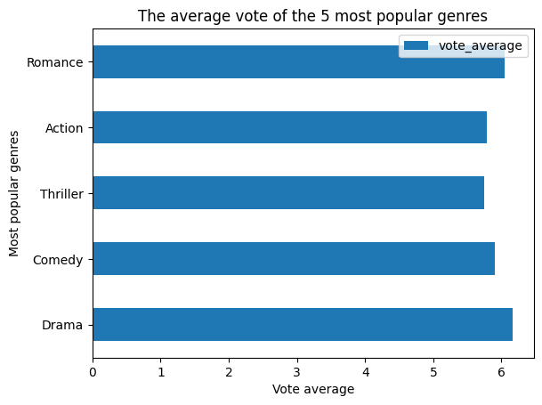

```python
variable_relation_with_genre('vote_average',"barh", False, "The average vote of the 5 most popular genres", xlabel = "Vote average", ylabel = "Most popular genres")
```

> The genre that have the highest vote average of the most popular genres is **Drama**

#### The relation of all of the genres with the vote_average

```python
# Making a dataframe for the unique genres with the average vote
data = pd.DataFrame(separated_genres.groupby('genres')['vote_average'].mean())
#sorting them
data.sort_values(by='vote_average', ascending = False, inplace = True)
data
```

| genres | vote_average |
| --- | --- |
| Documentary | 6.908462 |
| Music | 6.480392 |
| History | 6.410479 |
| Animation | 6.403147 |
| War | 6.297778 |
| Drama | 6.165546 |
| Crime | 6.124889 |
| Western | 6.083030 |
| Romance | 6.042874 |
| Family | 5.997563 |
| Foreign | 5.981383 |
| Mystery | 5.946790 |
| Adventure | 5.940585 |
| Comedy | 5.905167 |
| Fantasy | 5.863537 |
| TV Movie | 5.788024 |
| Action | 5.787752 |
| Thriller | 5.750671 |
| Science Fiction | 5.665582 |
| Horror | 5.337447 |

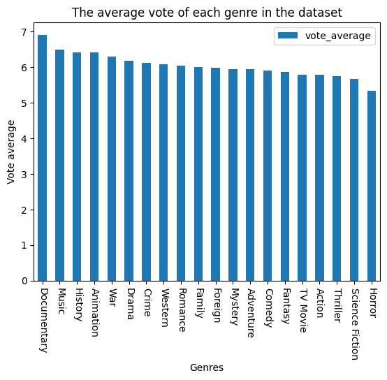

```python
# plotting it
data.plot.bar(rot = 270 , title = "The average vote of each genre in the dataset", xlabel = "Genres", ylabel = "Vote average")
```

> The genre that have the highest vote average of all of the genres is **Documentary**